Naturgeografi

# Digital opmåling af kystlinjen ved Røjle Klint

GIS-øvelse over 100 år

**Dato:** ____________________ **Gruppe / navne:** ____________________________________________

## Om øvelsen

I skal undersøge, hvordan kystlinjen ved Røjle Klint har flyttet sig gennem de sidste ca. 100 år. Det gør I ved i det digitale kortværktøj MiljøGIS at optegne kystlinjen på historiske målebordsblade og ortofoto (luftfotos) fra forskellige år og sammenligne, hvor der er eroderet materiale væk, og hvor der er aflejret nyt.

**NoteAdgang**

- Computer med internetadgang
- MiljøGIS: https://miljoegis.mim.dk/spatialmap?&profile=miljoegis-klimatilpasningsplaner

## Fremgangsmåde

1. Åbn MiljøGIS via linket ovenfor.
2. Orienter dig i rullemenuen i venstre side af skærmen, særligt de tre nederste (se Figur 1).

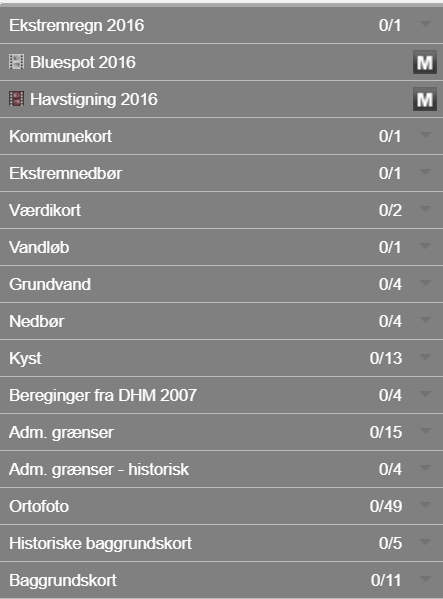

Figur 1: Rullemenuen i venstre side af skærmen.

3. Klik på **Baggrundskort**, og vælg **Skærmkort (DAF)**. Zoom ind på området nær Røjle Klint, til du ser noget i stil med Figur 2.

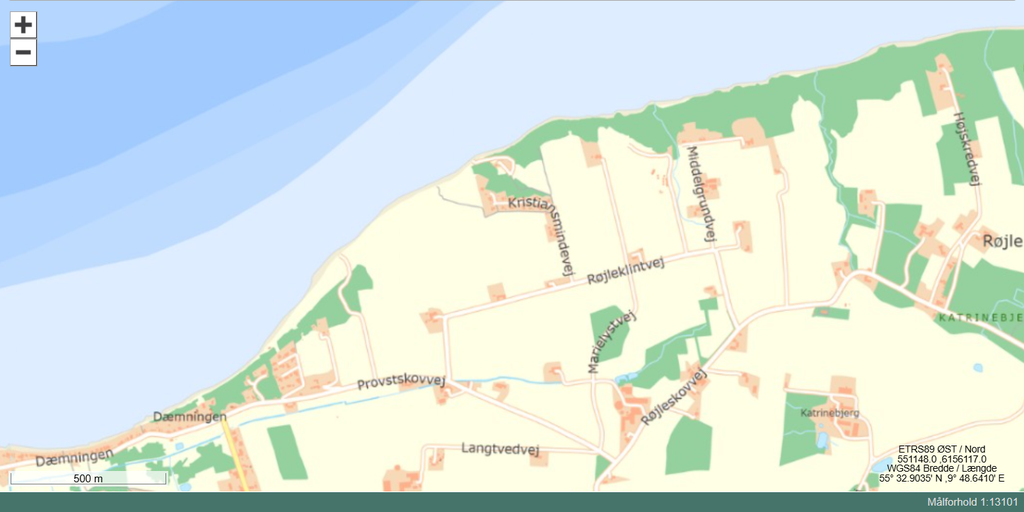

Figur 2: Skærmkort (DAF) zoomet ind på området omkring Røjle Klint.

**TipTip**

På ekskursionen parkerede vi i den nordlige ende af Kristiansmindevej og gik til stranden vest for Røjle Klint — det er også her, I skal kigge på kortet.

4. Zoom endnu mere ind, til dit skærmudsnit ligner Figur 3.

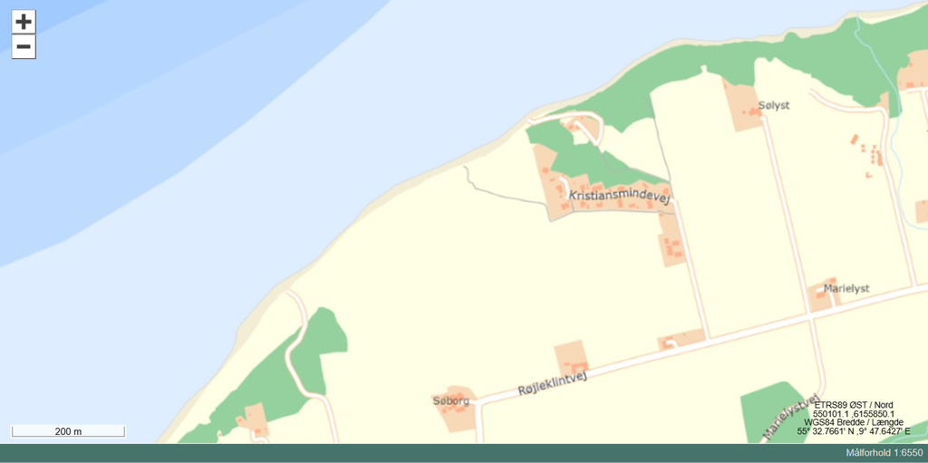

Figur 3: Yderligere indzoomet skærmudsnit ved Røjle Klint.

5. Uden at ændre på skærmudsnittet skal du nu klikke på **Historiske baggrundskort** og vælge **Høje målebordsblade 1842-1899**. Du bør få noget, der ser ud som Figur 4.

[figure not shown]

Figur 4: Høje målebordsblade 1842-1899 over området ved Røjle Klint.

6. Vælg **Værktøjer** fra menuen over kortet, og vælg **Mål længde/areal**.
7. Vælg **Mål afstand**, og tegn kystlinjen op ved at følge den med musen og klikke med jævne mellemrum, særligt når kystlinjen ændrer retning. Figur 5 viser et eksempel på, hvordan det kan se ud — indsæt herefter dit eget skærmprint af resultatet:

[figure not shown]

Figur 5: Eksempel på en optegnet kystlinje på Høje målebordsblade 1842-1899.

*(Indsæt eget skærmprint her)*

8. VIGTIGT! Uden at slette kystlinjen på det gamle kort skal du nu klikke på kortlaget **Lave målebordsblade 1901-1971** i menuen til venstre (Historiske baggrundskort). Notér, hvor den gamle kystlinje afviger fra den nye: hvor er der fjernet materiale, og hvor er der tilført materiale?
9. Tegn kystlinjen op igen med samme værktøj, og indsæt et skærmprint her:

*(Indsæt eget skærmprint her)*

10. Vælg så **Ortofoto 1954 (Hexagon)**, og sammenlign med kystlinjen fra Lave målebordsblade. Hvad har ændret sig, og *hvor* er kystlinjen blevet ændret? Indtegn den nye kystlinje, tag et skærmprint, og indsæt det her:

*(Indsæt eget skærmprint her)*

11. Vælg til sidst **Ortofoto seneste**, og sammenlign med kystlinjen for Ortofoto 1954. Hvilke ændringer kan du få øje på, og hvor? Indtegn den nye kystlinje, og indsæt et skærmprint her:

*(Indsæt eget skærmprint her)*

## Databehandling

1. Vælg tre faste punkter langs kysten — fx ved den vestlige ende, midt for klinten og ved den østlige ende af jeres udsnit. Brug **Mål afstand** til at måle den vinkelrette afstand fra kystlinjen på det ældste kort til kystlinjen på hvert af de nyere kort. Skriv tallene i Tabel 1 med fortegn: negativt, hvor kysten er rykket ind i land (erosion), positivt, hvor den er rykket ud (aflejring).

Tabel 1: Kystlinjens forskydning i forhold til det ældste kort. Årstallet for målebordsbladene aflæses i kortets signaturforklaring eller sættes til midten af perioden.

| Kortlag | Årstal | Punkt 1 (m) | Punkt 2 (m) | Punkt 3 (m) |
| --- | --- | --- | --- | --- |
| Høje målebordsblade |  | 0 | 0 | 0 |
| Lave målebordsblade |  |  |  |  |
| Ortofoto 1954 | 1954 |  |  |  |
| Ortofoto seneste |  |  |  |  |

2. Beregn for hvert punkt den gennemsnitlige forskydning pr. år mellem det ældste og det nyeste kort:

$$\text{Gennemsnitlig forskydning} = \frac{\text{forskydning (m)}}{\text{antal år}} \quad (\text{m/år})$$

3. Beregn også forskydningen pr. år for perioden 1954 til i dag alene, og sammenlign med hele perioden. Er erosionen gået hurtigere eller langsommere i den seneste periode?
4. Sammenhold tallene med jeres skærmprint: hvor har kysten flyttet sig mest, og hvor mindst?

## Journalspørgsmål

1. Beskriv, hvordan kystlinjen ved Røjle Klint har ændret sig gennem de ca. 100 år. Hvor er der sket erosion, og hvor er der sket aflejring?
2. Forklar, hvilke processer der fjerner materiale fra en klint, og hvad der sker med materialet bagefter. Brug begreberne *bølgeerosion*, *skred* og *materialevandring langs kysten*.
3. Hvilken retning har den fremherskende materialevandring ved Røjle Klint ud fra jeres kort? Begrund svaret med, hvor der er aflejret materiale.
4. Hvorfor er de gamle målebordsblade mindre præcise end ortofotos, og hvilken betydning har det for, hvor sikre jeres målte forskydninger er?
5. Hvilke konsekvenser kan en fortsat kysttilbagerykning have for bygninger, veje og landbrug i området? Diskutér fordele og ulemper ved kystsikring, fx høfder eller skræntfodsbeskyttelse, både lokalt og for kysten længere nede ad materialevandringen.
6. Hvordan forventer I, at stigende havniveau og flere kraftige storme i et varmere klima vil påvirke erosionen ved Røjle Klint?

## Ekstraopgaver

1. Find Røjle Klint på det sammenstykkede foto af Danmark, **Ortofoto 1/49**, ved at klikke på **seneste** (se Figur 6).

[figure not shown]

Figur 6: Det sammenstykkede ortofoto over Danmark (Ortofoto 1/49).

2. Klik på **“Optagetidspunkt seneste”** (se Figur 7).

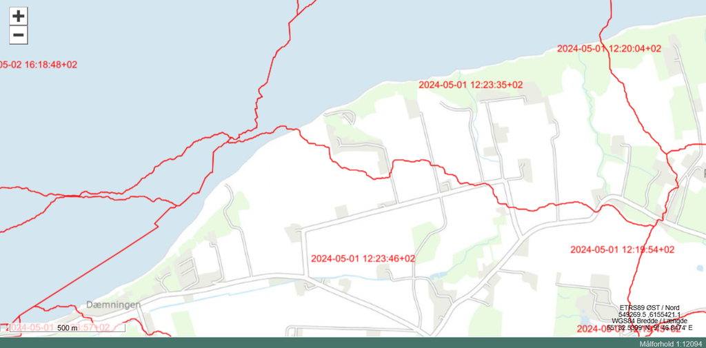

Figur 7: Visning af optagetidspunkt for det seneste ortofoto.

3. Hvornår er billederne taget?
4. Hvilken dato har vi i dag?
5. Klik på det ældste ortofoto, **DDOland 1954 (Hexagon)**, og se på skærmprintet i Figur 8.

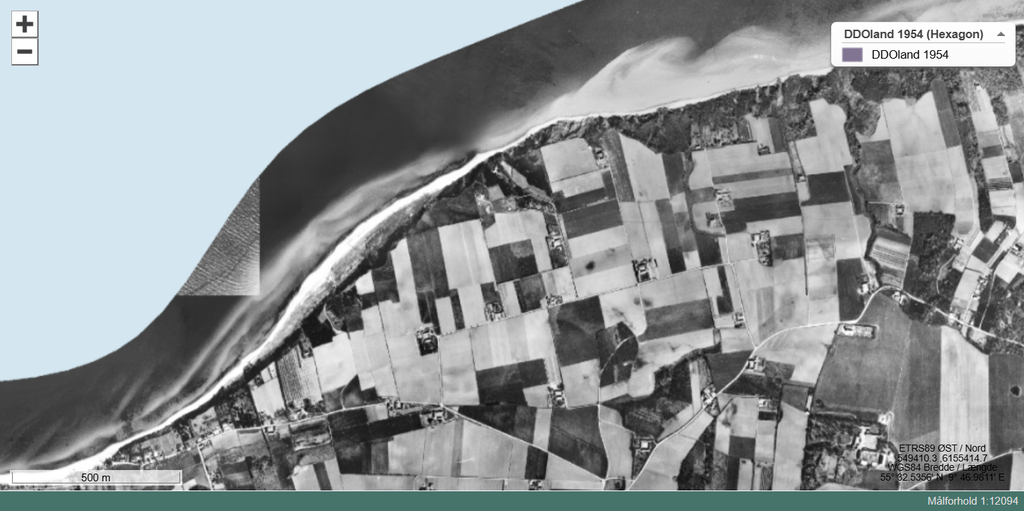

Figur 8: DDOland 1954 (Hexagon) — ortofoto af området ved Røjle Klint.

6. Klik på det næstældste ortofoto, **DDOland 1995 (Hexagon)**, og se på skærmprintet i Figur 9.

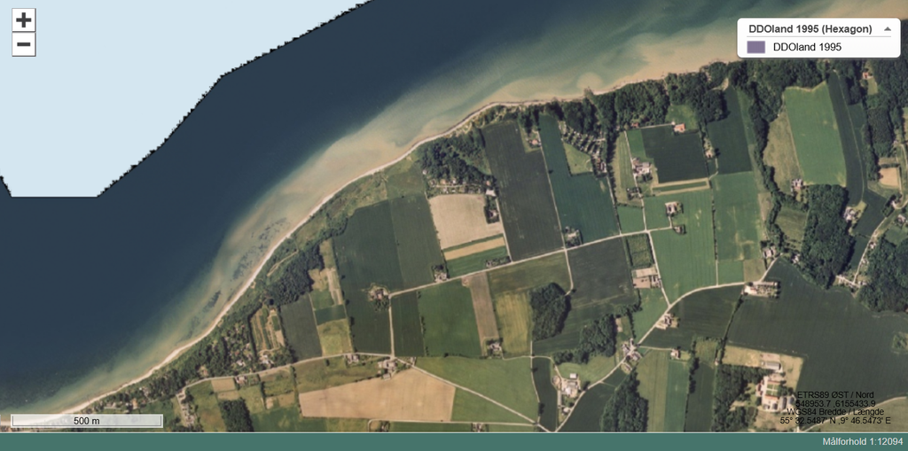

Figur 9: DDOland 1995 (Hexagon) — ortofoto af området ved Røjle Klint.

7. Hvad er der sket med stranden vest for Røjle Klint fra 1954 til 1995? (Og hvad er der sket med størrelsen på markerne?)